ADP · Teste de autoavaliação

# Homogeneidade de variâncias e esfericidade

O que é e como checar

Os histogramas mostram a glicemia de jejum em dois grupos. Qual dos grupos varia mais?

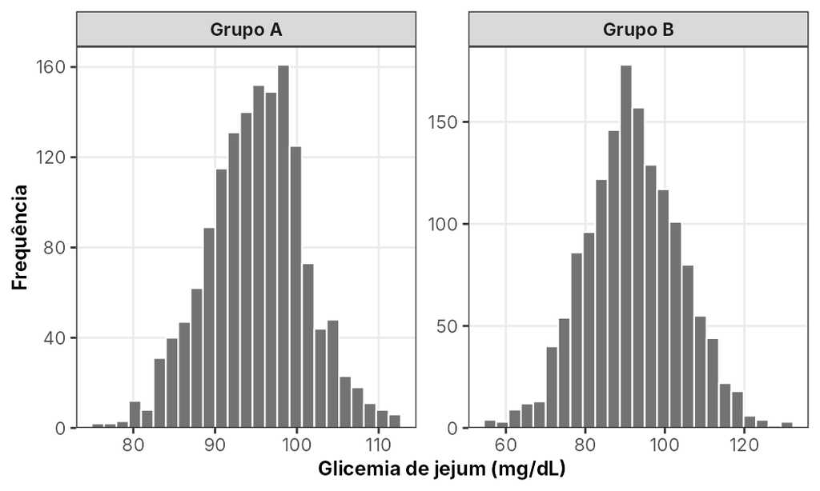

Glicemia de jejum em dois grupos de 1.500 pessoas (dados fictícios).

1. O Grupo B: os histogramas parecem iguais, mas o eixo x de B cobre uma faixa de valores cerca de duas vezes maior.
2. Os dois variam igualmente, porque os histogramas têm a mesma largura.
3. O Grupo A, porque a média dele é um pouco maior.
4. Não dá para ter nenhuma ideia sem o teste de Levene.

Num estudo experimental com estudantes de enfermagem, os autores queriam mostrar que o grupo experimental (GE) e o grupo controle (GC) eram parecidos antes da intervenção. Leia o trecho. Se o teste usado tivesse sido mesmo o de Levene, o que ele permitiria concluir?

> “Antes da realização dos cenários de SC (T0), com recurso à estatística do teste de Levene, não foram encontradas diferenças com significado estatístico entre os GE e GC nas variáveis idade (313; p=0,786), conhecimentos (226; p=0,055) e TD (265; p=0,258), demonstrando a homogeneidade da amostra relativamente a estes dados.”

> SC: simulação clínica; TD: tomada de decisão.

> Fonte: DUARTE, H. M. S. et al. Estudo comparativo entre simulação de alta-fidelidade e simulação de média-fidelidade na tomada de decisão de estudantes de enfermagem: estudo experimental. Revista Latino-Americana de Enfermagem, v. 32, e4269, 2024. Licença CC BY.
1. Apenas que a variabilidade da idade, dos conhecimentos e da tomada de decisão não difere entre os grupos. O teste nada diz sobre os grupos terem médias parecidas.
2. Que os grupos tinham médias parecidas de idade, conhecimentos e tomada de decisão, como os autores afirmam.
3. Que as três variáveis seguem distribuição normal nos dois grupos.
4. Que os grupos diferem em conhecimentos, já que p = 0,055 está muito perto de 0,05.

Uma variável foi medida nos mesmos 30 participantes em três momentos. Uma colega viu que os desvios-padrão dos três momentos são quase iguais e concluiu: *“o pressuposto de esfericidade está garantido”*. O raciocínio dela está certo?

> | Momento | Média | Desvio-padrão |
> | --- | --- | --- |
> | T1 | 79,5 | 10,5 |
> | T2 | 76,1 | 10,6 |
> | T3 | 76,9 | 10,4 |

> Dados fictícios.
1. Não: a esfericidade se refere às variâncias das diferenças entre os momentos (T2 − T1, T3 − T1 e T3 − T2), e é para elas que se deve olhar.
2. Sim: se cada momento tem a mesma variância, as diferenças entre eles também terão.
3. Sim, desde que o teste de Levene entre os três momentos dê p > 0,05.
4. Não: para haver esfericidade, as médias dos três momentos também precisam ser iguais.

Um pesquisador mediu a ansiedade de 25 pacientes antes e depois de uma intervenção (dois momentos) e quis verificar o pressuposto de esfericidade. O software não mostrou nenhum resultado para o teste de Mauchly. Por quê?

1. Com dois momentos, existe uma única diferença (depois − antes), e uma variância não tem com quem ser comparada: a esfericidade é sempre atendida.
2. Porque 25 pacientes é pouco para o teste ser calculado.
3. Porque, com dois momentos, o correto é usar o teste de Levene entre o antes e o depois.
4. Porque houve algum erro na organização dos dados, e o pressuposto precisa ser verificado de outra forma.